This markdown document describes the steps used to analyze data from a personal activity monitoring device. This data is a two-month recording of steps taken in 5 minutes intervals each day, from an anonymous individual.

###Loading and preprocessing the data

First, we unzip the `activity.zip` file and read it into R using the following code:

```r
unzip("activity.zip")
activity_data <- read.csv("activity.csv", header=T)
```

To make sure everything went right, let's show the first few lines of the dataset:

```r
head(activity_data)
```

```
##   steps       date interval
## 1    NA 2012-10-01        0
## 2    NA 2012-10-01        5
## 3    NA 2012-10-01       10
## 4    NA 2012-10-01       15
## 5    NA 2012-10-01       20
## 6    NA 2012-10-01       25
```

Now, let's process the date to an object of class POSIXct, using the function `ymd()` from the package `lubridate`:

```r
#First, load package
library(lubridate)

#Then apply the function ymd()
activity_data$date <- ymd(activity_data$date)
```

###What is mean total number of steps taken per day?

The next step is to answer the question **What is mean total number of steps taken per day?**. In this step, we have to create a vector containing the total number of steps per day. The total number of steps is the per day sum of steps. Using `split()` and `sapply()`, we can simply achieve that:

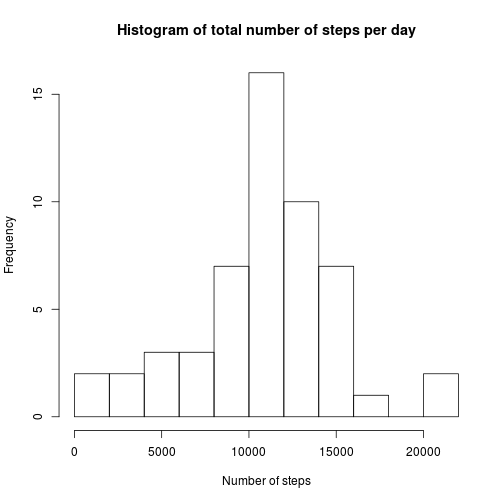

```r
#First create a vector with the total number of steps per day
steps_day <- sapply(split(activity_data$steps, activity_data$date), sum)

#Then, create a histogram with the distribution of the total number of steps taken each day (NAs omitted)
hist(na.omit(steps_day), n=10, main="Histogram of total number of steps per day", xlab="Number of steps")
```

```r
#Finaly, create an objetct with the mean and meadian total number of steps taken per day
total_mean_steps <- as.character(round(mean(na.omit(steps_day)), digits=2))
total_median_steps <- median(na.omit(steps_day))
```

Based on the distribution of the steps per day, the mean total number of steps taken per day was **10766.19** and the median was **10765**.

###What is the average daily activity pattern?

Here, we will show the average daily activity pattern. First, we will have to calculate the mean number of steps across all days for each of the 5 minutes interval. With a similar approach, we can achieve that using `split()` and `sapply()`:

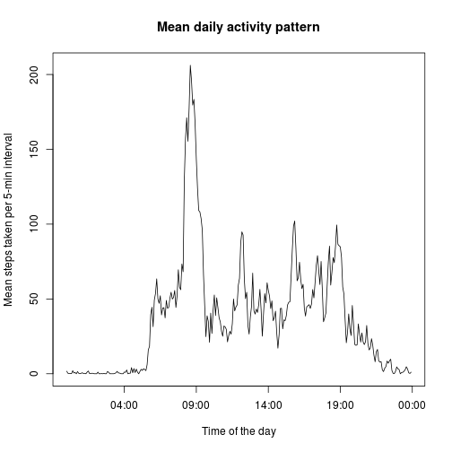

```r
#First create a vector with the mean number of steps per interval, across all days
mean_steps_interval <- sapply(split(activity_data$steps, activity_data$interval), mean, na.rm=T)

#Then, plot a time series of the 5-minute interval (x-axis) and the average number of steps taken, averaged across all days (y-axis)

#Create the sequence and format to show only Hours and Minutes:
interval5min <- seq(as.POSIXct("00:00", format="%H:%M"), by=300, len=288)

#Plot
plot(interval5min, na.omit(mean_steps_interval), type="l", main="Mean daily activity pattern", ylab="Mean steps taken per 5-min interval", xlab="Time of the day")
```

To find out which 5-min interval contains the maximum number of steps, we can create a new data frame with the time of the day (sequence of 5 minute intervals) and the average number of steps taken across all days for each interval, and look for the maximum value of the average

```r
#Format time object to show only hours and minutes
interval5min_H_M <- format(interval5min, "%H:%M")

#Create data frame
mean_daily_act <- data.frame(interval=interval5min_H_M, mean_steps=na.omit(mean_steps_interval))

#Get the index and interval of the maximum number of steps
max_mean_step_interval <- mean_daily_act[which.max(mean_daily_act$mean_steps),1]
```

Therefore, the interval containing the maximum number of steps, on average, is the one starting at **08:35**.

###Imputing missing values

The following code calculates the total number of `NA` in the dataset.

```r
#Total number of missing values in the dataset
sum(is.na(activity_data$steps))
```

```
## [1] 2304
```

There are **2304** 5-min intervals missing number of steps in the two-month recording.

We will use the mean activity of each interval across all days which were recorded to replace missing data for that intervals. This information is already stored into the vector `mean_daily_act$mean_steps`.

The strategy will consist of splitting `activity_data` into a list of data frames per interval, replace all the NAs by the mean activity for that interval

```r
#Split activity_data by interval
act_list <- split(activity_data, activity_data$interval)


#Iterate for each data.frame (interval) and substitute NAs for the mean steps for that interval
for (i in 1:length(act_list)){
        act_list[[i]]$steps[is.na(act_list[[i]]$steps)] <- mean_daily_act$mean_steps[i]
}

#Unsplit to convert to data frame again, using the same activity_data$interval factor
imputed_activity_data <- unsplit(act_list, activity_data$interval)

#Check that this new data frame does not have any NAs
sum(is.na(imputed_activity_data))
```

```
## [1] 0
```

Now, lets make the histogram and calculate the mean and median total number of steps taken each day:

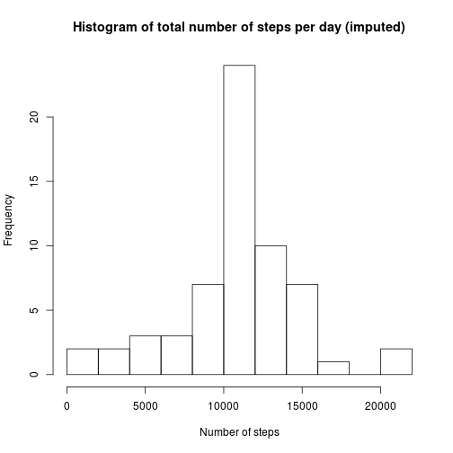

```r
#Calculate new total number of steps per day (round decimal number to floor)
new_steps_day <- floor(sapply(split(imputed_activity_data$steps, imputed_activity_data$date), sum))

#Then, create a histogram with the distribution of the total number of steps taken each day in the imputed data
hist(new_steps_day, n=10, main="Histogram of total number of steps per day (imputed)", xlab="Number of steps")
```

```r
#Finaly, create objetct with the mean and meadian total number of steps taken per day on the imputed data
new_total_mean_steps <- as.character(round(mean(new_steps_day), digits=2))
new_total_median_steps <- as.character(median(floor(new_steps_day)))
```

On the imputed data, the mean total number of steps taken per day was **10766.16** and the median was **10766** (as compared to **10766.19** and **10765**, respectively, before imputation). Thus, in terms of central tendency measures, imputation did not affect the results.

But let's compare both histograms (now using `ggplot2`):

```
## stat_bin: binwidth defaulted to range/30. Use 'binwidth = x' to adjust this.
## stat_bin: binwidth defaulted to range/30. Use 'binwidth = x' to adjust this.
```

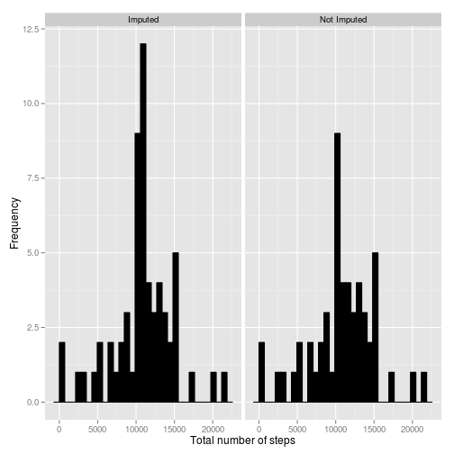

```r
library(ggplot2)
library(scales)

#Create and format data frame for plot creation
steps_day_df <- cbind(c(steps_day, new_steps_day), rep(c("Not Imputed", "Imputed"), each=length(new_steps_day)))
rownames(steps_day_df) <- 1:nrow(steps_day_df)
colnames(steps_day_df) <- c("steps", "imp")
steps_day_df <- as.data.frame(steps_day_df)
steps_day_df$steps <- as.numeric(as.character(steps_day_df$steps))

#Plot histogram in facets
ggplot(steps_day_df, aes(x=steps)) + geom_histogram(colour="black", fill="black") +
    facet_grid(. ~ imp) + xlab("Total number of steps") + ylab("Frequency")
```

As we can see, no changes in the central tendency measures, but we can see a higher frequency of the center bin in the histogram.

###Are there differences in activity patterns between weekdays and weekends?

Here, we will create a new factor variable containing the weekday with the function `weekdays()`:

```r
#First set locale for English weekdays names
my_locale <- Sys.getlocale(category = "LC_TIME") #save original locale time
Sys.setlocale(category = "LC_TIME", locale= "en_US.UTF-8")
```

```
## [1] "en_US.UTF-8"
```

```r
#Create factor variable for weekday names (which is already in POSIXct format) and for weekend versus weekdays
imputed_activity_data$weekday <- weekdays(imputed_activity_data$date)
imputed_activity_data$week[which(imputed_activity_data$weekday=="Saturday" | imputed_activity_data$weekday=="Sunday")] <- "Weekend"
imputed_activity_data$week[which(!imputed_activity_data$week=="Weekend")] <- "Weekday"

#Turn back original system locale for time
Sys.setlocale(category = "LC_TIME", locale= my_locale)
```

```
## [1] "pt_BR.UTF-8"
```

Then, we will plot a panel plot to compare activity from weekdays versus weekends:

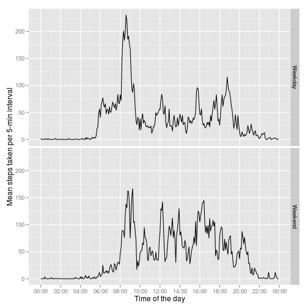

```r
#Split data frame by weekday x weekends
week_list <- split(imputed_activity_data, imputed_activity_data$week, imputed_activity_data$interval)

#Create a vector with the mean number of steps per interval, across each weekday
weekday_mean_steps_interval <- sapply(split(week_list$Weekday$steps, week_list$Weekday$interval), mean)

#And across each weekend day
weekend_mean_steps_interval <- sapply(split(week_list$Weekend$steps, week_list$Weekend$interval), mean)

#Then, plot a time series of the 5-minute interval (x-axis) and the average number of steps taken, averaged across all weekdays or weekends(y-axis) using ggplot

#Create and format df
week_df <- data.frame(rep(interval5min,2), c(weekday_mean_steps_interval, weekend_mean_steps_interval), c(rep("Weekday", length(weekday_mean_steps_interval)),rep("Weekend", length(weekend_mean_steps_interval))))
colnames(week_df) <- c("interval","mean_steps","week")

#Plot
ggplot(week_df, aes(interval, mean_steps)) +
        geom_line() +
        scale_x_datetime(breaks=("2 hour"), labels=date_format("%H:%M")) +
        xlab("Time of the day") +
        ylab("Mean steps taken per 5-min interval") +
        facet_grid(week ~ .)
```

Based on this data, we can see differences in patterns of mean daily activity for each interval of weekdays and weekends.